# MD4 Demo

Stephen Vaisey

2022-09-22

```r
library(tidyverse)
```

I’m going to go through the examples in the *ModernDive* text.

### Democracy Scores

If you haven’t done this before you can load data from your hard drive instead of grabbing it off the internet. Here’s a link to some data: https://moderndive.com/data/dem_score.csv. If you save this in a folder called **`MD-Data`** somewhere in your project folder, the code below will work.

There’s a small wrinkle here that I will explain in class. The problem is that the file I’m working in is in the `demos` subfolder and the data I need is in a different subfolder (`MD-data`). When projects get complicated, the **`here`** package is super useful. You will have to install it if this your first time using it on your current machine.

```r
library(here)
dem_score <- read_csv(here("MD-Data", "dem_score.csv"))
dem_score |> head(10)
```

```
## # A tibble: 10 × 10
##    country    `1952` `1957` `1962` `1967` `1972` `1977` `1982` `1987` `1992`
##    <chr>       <dbl>  <dbl>  <dbl>  <dbl>  <dbl>  <dbl>  <dbl>  <dbl>  <dbl>
##  1 Albania        -9     -9     -9     -9     -9     -9     -9     -9      5
##  2 Argentina      -9     -1     -1     -9     -9     -9     -8      8      7
##  3 Armenia        -9     -7     -7     -7     -7     -7     -7     -7      7
##  4 Australia      10     10     10     10     10     10     10     10     10
##  5 Austria        10     10     10     10     10     10     10     10     10
##  6 Azerbaijan     -9     -7     -7     -7     -7     -7     -7     -7      1
##  7 Belarus        -9     -7     -7     -7     -7     -7     -7     -7      7
##  8 Belgium        10     10     10     10     10     10     10     10     10
##  9 Bhutan        -10    -10    -10    -10    -10    -10    -10    -10    -10
## 10 Bolivia        -4     -3     -3     -4     -7     -7      8      9      9
```

This is what is called “wide form.” A lot of data comes like this. It’s not “tidy.” Let’s make it tidy.

```r
ds_tidy <- dem_score |>
  pivot_longer(cols = `1952`:`1992`,    # the names of the columns with the values
               names_to = "year",       # the name of the new key variable
               values_to = "score") |>  # the name of the new value variable
  mutate(yearnum = as.integer(year))    # (see below)

ds_tidy |> head(20)
```

```
## # A tibble: 20 × 4
##    country   year  score yearnum
##    <chr>     <chr> <dbl>   <int>
##  1 Albania   1952     -9    1952
##  2 Albania   1957     -9    1957
##  3 Albania   1962     -9    1962
##  4 Albania   1967     -9    1967
##  5 Albania   1972     -9    1972
##  6 Albania   1977     -9    1977
##  7 Albania   1982     -9    1982
##  8 Albania   1987     -9    1987
##  9 Albania   1992      5    1992
## 10 Argentina 1952     -9    1952
## 11 Argentina 1957     -1    1957
## 12 Argentina 1962     -1    1962
## 13 Argentina 1967     -9    1967
## 14 Argentina 1972     -9    1972
## 15 Argentina 1977     -9    1977
## 16 Argentina 1982     -8    1982
## 17 Argentina 1987      8    1987
## 18 Argentina 1992      7    1992
## 19 Armenia   1952     -9    1952
## 20 Armenia   1957     -7    1957
```

Why do you think I added that `mutate()` step? In what situations might that matter? (I will show a better way later but let’s go with this for now.)

Let’s take a brief digression and see. Let’s keep only a few countries.

```r
ds_tidy_small <- ds_tidy |>
  filter(country %in% c("China",
                        "Korea, Rep.",
                        "Mexico",
                        "Russia",
                        "Argentina"))
```

Here’s the version with `year` (a character variable).

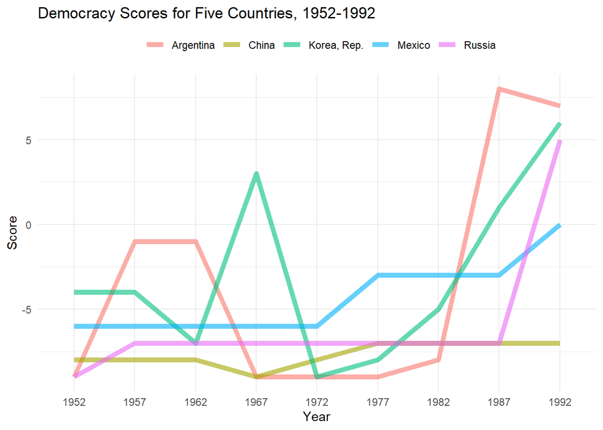

```r
ggplot(ds_tidy_small,
       aes(x = year,
           y = score,
           group = country,
           color = country)) +
  geom_line(size = 2,
            alpha = .6) +
  theme_minimal() +
  labs(x = "Year",
       y = "Score",
       color = "",
       title = "Democracy Scores for Five Countries, 1952-1992") +
  theme(legend.position = "top")
```

Here’s the version with `yearnum` (an integer variable).

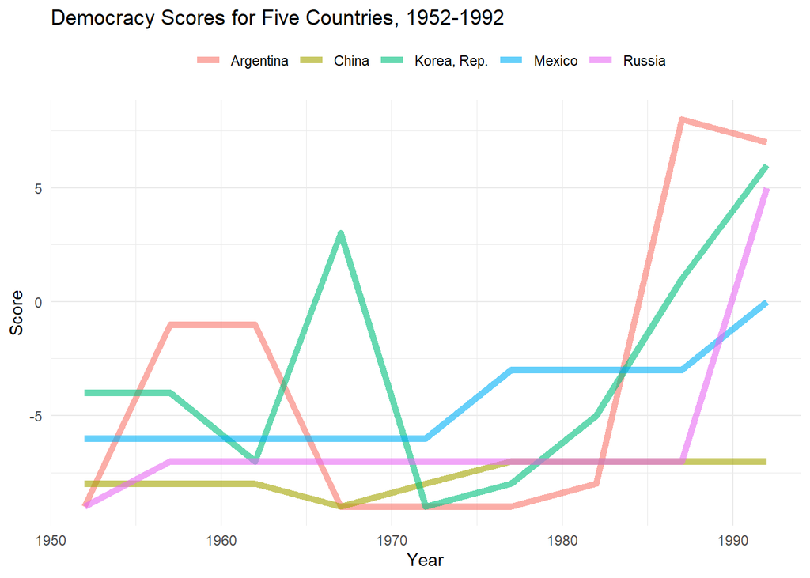

```r
ggplot(ds_tidy_small,
       aes(x = yearnum,
           y = score,
           group = country,
           color = country)) +
  geom_line(size = 2,
            alpha = .6) +
  theme_minimal() +
  labs(x = "Year",
       y = "Score",
       color = "",
       title = "Democracy Scores for Five Countries, 1952-1992") +
  theme(legend.position = "top")
```

The second version (`yearnum`) is an actual numeric variable. So it treats it differently than the character version.

We could do this as part of the `pivot_longer()` function like this:

```r
ds_tidy <- dem_score |>
  pivot_longer(`1952`:`1992`,
               names_to = "year",
               values_to = "score",
               names_transform = list(year = as.integer))

ds_tidy |> head(20)
```

```
## # A tibble: 20 × 3
##    country    year score
##    <chr>     <int> <dbl>
##  1 Albania    1952    -9
##  2 Albania    1957    -9
##  3 Albania    1962    -9
##  4 Albania    1967    -9
##  5 Albania    1972    -9
##  6 Albania    1977    -9
##  7 Albania    1982    -9
##  8 Albania    1987    -9
##  9 Albania    1992     5
## 10 Argentina  1952    -9
## 11 Argentina  1957    -1
## 12 Argentina  1962    -1
## 13 Argentina  1967    -9
## 14 Argentina  1972    -9
## 15 Argentina  1977    -9
## 16 Argentina  1982    -8
## 17 Argentina  1987     8
## 18 Argentina  1992     7
## 19 Armenia    1952    -9
## 20 Armenia    1957    -7
```

### Drinks example

Let’s grab the next dataset from the **`fivethirtyeight`** package. You will need to install it if you haven’t already.

The dataset is called `drinks`. You can find out more about it by typing `?fivethirtyeight::drinks` in the console (i.e., **NOT** in your Markdown document).

```r
library(fivethirtyeight)
data(drinks)
glimpse(drinks)
```

```
## Rows: 193
## Columns: 5
## $ country                      <chr> "Afghanistan", "Albania", "Algeria", "And…
## $ beer_servings                <int> 0, 89, 25, 245, 217, 102, 193, 21, 261, 2…
## $ spirit_servings              <int> 0, 132, 0, 138, 57, 128, 25, 179, 72, 75,…
## $ wine_servings                <int> 0, 54, 14, 312, 45, 45, 221, 11, 212, 191…
## $ total_litres_of_pure_alcohol <dbl> 0.0, 4.9, 0.7, 12.4, 5.9, 4.9, 8.3, 3.8, …
```

This is the average number of servings of this drink type per person in each country. (The data are from 2010.)

Let’s look at the structure.

```r
drinks |> head()
```

```
## # A tibble: 6 × 5
##   country           beer_servings spirit_servings wine_servings total_litres_o…¹
##   <chr>                     <int>           <int>         <int>            <dbl>
## 1 Afghanistan                   0               0             0              0
## 2 Albania                      89             132            54              4.9
## 3 Algeria                      25               0            14              0.7
## 4 Andorra                     245             138           312             12.4
## 5 Angola                      217              57            45              5.9
## 6 Antigua & Barbuda           102             128            45              4.9
## # … with abbreviated variable name ¹total_litres_of_pure_alcohol
```

This dataset isn’t tidy either. And since we’re interested in servings only at this point, let’s get rid of the `total_litres` column.

Take a moment and imagine what a tidy version of this dataset would look like! (Seriously, do it.)

```r
drinks_long <- drinks |>
  select(-total_litres_of_pure_alcohol) |>
  pivot_longer(cols = -country,
               names_to = "type",
               values_to = "servings")

drinks_long |> head(10)
```

```
## # A tibble: 10 × 3
##    country     type            servings
##    <chr>       <chr>              <int>
##  1 Afghanistan beer_servings          0
##  2 Afghanistan spirit_servings        0
##  3 Afghanistan wine_servings          0
##  4 Albania     beer_servings         89
##  5 Albania     spirit_servings      132
##  6 Albania     wine_servings         54
##  7 Algeria     beer_servings         25
##  8 Algeria     spirit_servings        0
##  9 Algeria     wine_servings         14
## 10 Andorra     beer_servings        245
```

The `type` names are a bit redundant. We can rename them with `rename()` but we have to do that before the pivot. Otherwise, it’s trickier. So let’s do it again.

```r
drinks_long <- drinks |>
  rename(beer = beer_servings,
         spirit = spirit_servings,
         wine = wine_servings) |>
  select(-total_litres_of_pure_alcohol) |>
  pivot_longer(cols = -country,
               names_to = "type",
               values_to = "servings")

drinks_long |> head(10)
```

```
## # A tibble: 10 × 3
##    country     type   servings
##    <chr>       <chr>     <int>
##  1 Afghanistan beer          0
##  2 Afghanistan spirit        0
##  3 Afghanistan wine          0
##  4 Albania     beer         89
##  5 Albania     spirit      132
##  6 Albania     wine         54
##  7 Algeria     beer         25
##  8 Algeria     spirit        0
##  9 Algeria     wine         14
## 10 Andorra     beer        245
```

Having data in this form makes graphing easier. Let’s try looking at drink consumption in a few countries.

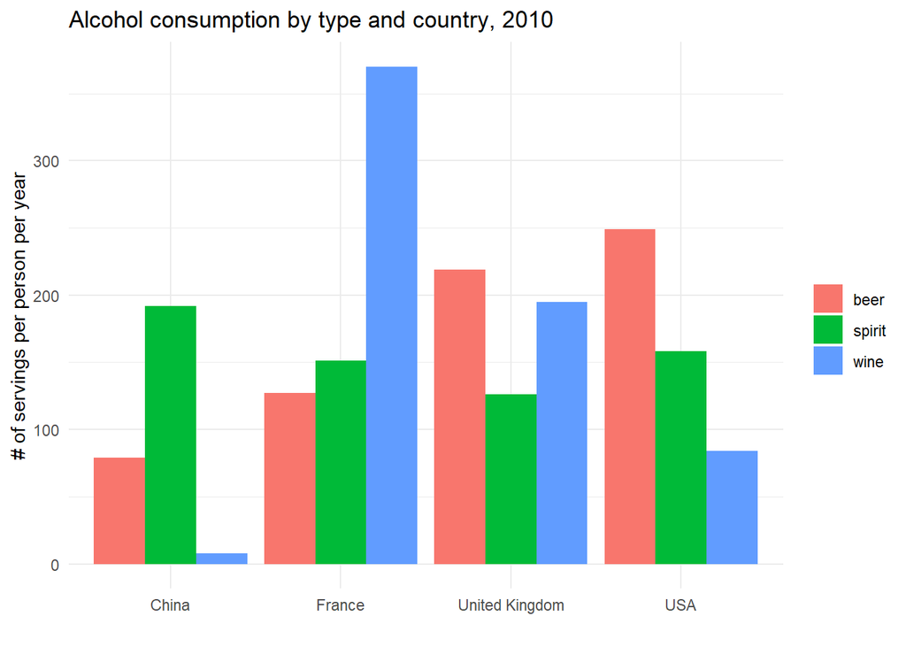

```r
drinks_long |>
  filter(country %in% c("USA",
                        "United Kingdom",
                        "France",
                        "China")) |>
  ggplot(
    aes(x = country,
        y = servings,
        fill = type)) +
  geom_bar(stat = "identity",
           position = "dodge") +
  labs(x = "",
       y = "# of servings per person per year",
       title = "Alcohol consumption by type and country, 2010",
       fill = "") +
  theme_minimal()
```

If we remove `position_dodge()` we’ll get a stacked bar chart. In which situations would one or the other be more useful?

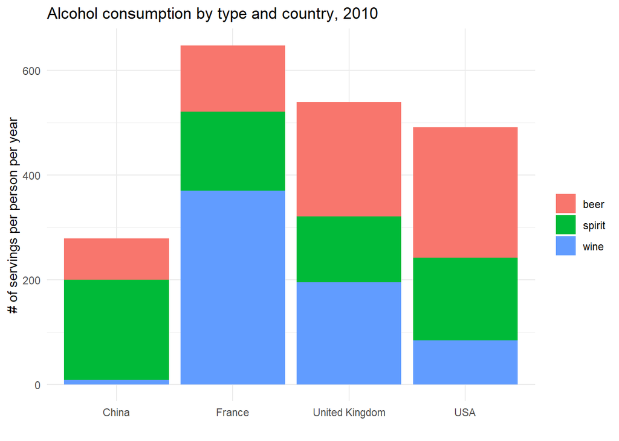

```r
drinks_long |>
  filter(country %in% c("USA",
                        "United Kingdom",
                        "France",
                        "China")) |>
  ggplot(
    aes(x = country,
        y = servings,
        fill = type)) +
  geom_bar(stat = "identity") +
  labs(x = "",
       y = "# of servings per person per year",
       title = "Alcohol consumption by type and country, 2010",
       fill = "") +
  theme_minimal()
```

Here the x-axis is sorted alphabetically but we could sort by, say, total number of servings. Let’s see how.

```r
drinks_long <- drinks_long |>
  group_by(country) |>
  mutate(tot_servings = sum(servings)) |>
  ungroup()
```

What’s new?

```r
glimpse(drinks_long)
```

```
## Rows: 579
## Columns: 4
## $ country      <chr> "Afghanistan", "Afghanistan", "Afghanistan", "Albania", "…
## $ type         <chr> "beer", "spirit", "wine", "beer", "spirit", "wine", "beer…
## $ servings     <int> 0, 0, 0, 89, 132, 54, 25, 0, 14, 245, 138, 312, 217, 57, …
## $ tot_servings <int> 0, 0, 0, 275, 275, 275, 39, 39, 39, 695, 695, 695, 319, 3…
```

Now we can use this information to reorder the x-axis in descending order by number of total servings.

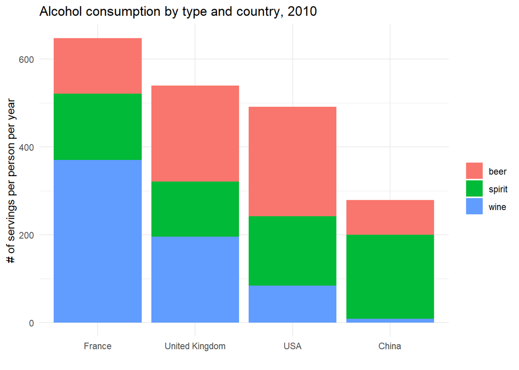

```r
drinks_long |>
  filter(country %in% c("USA",
                        "United Kingdom",
                        "France",
                        "China")) |>
  ggplot(
    aes(x = reorder(country, -tot_servings),
        y = servings,
        fill = type)) +
  geom_bar(stat = "identity") +
  labs(x = "",
       y = "# of servings per person per year",
       title = "Alcohol consumption by type and country, 2010",
       fill = "") +
  theme_minimal()
```

We could also change the x and y axes using `coord_flip()` (and removing the `-` from the reorder variable if we want).

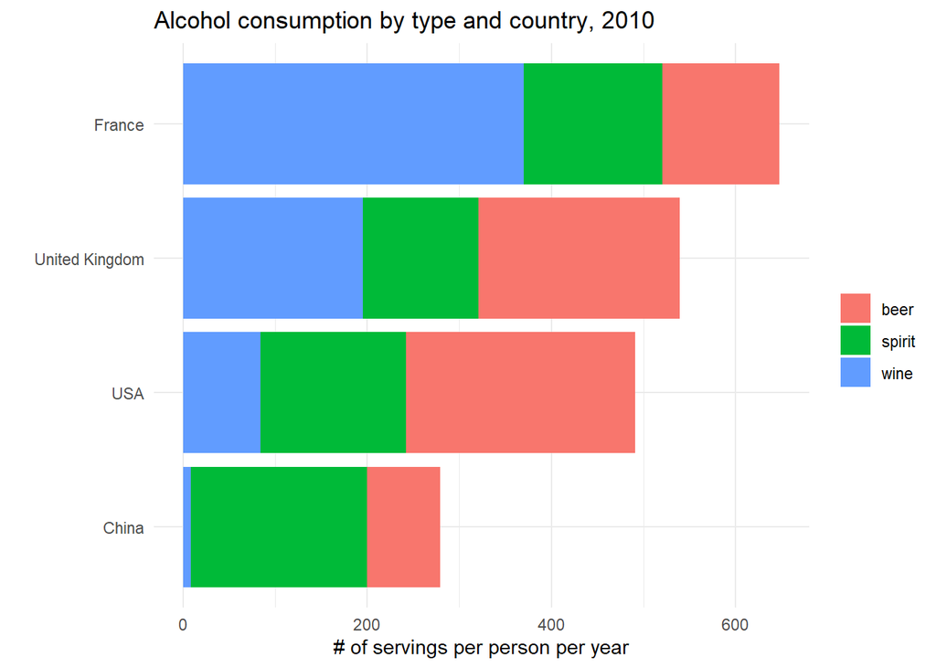

```r
drinks_long |>
  filter(country %in% c("USA",
                        "United Kingdom",
                        "France",
                        "China")) |>
  ggplot(
    aes(x = reorder(country, tot_servings),
        y = servings,
        fill = type)) +
  geom_bar(stat = "identity") +
  labs(x = "",
       y = "# of servings per person per year",
       title = "Alcohol consumption by type and country, 2010",
       fill = "") +
  theme_minimal() +
  coord_flip()
```